# Comparing Forecast Methods

### Comparing Forecast Methods

By: Nimrod Dvir

```python
import numpy as np
import pandas as pd
```

```python
pd.plotting.register_matplotlib_converters()
import matplotlib.pyplot as plt
%matplotlib inline
import seaborn as sns
import datetime
from scipy import stats
```

I start with loading and inspecting the data:

```python
wind_actual_generation = pd.read_csv(r'C:\Users\dvirn\Documents\Data Science\wind_actual_generation.csv', parse_dates = True)
wind_forecast = pd.read_csv(r'C:\Users\dvirn\Documents\Data Science\wind_forecast.csv', parse_dates = True)
```

```python
wind_actual_generation.head()
```

|  | 2013-09-08 03:55:00+00:00 | 2680.85 |
| --- | --- | --- |
| 0 | 2013-09-08 04:00:00+00:00 | 2680.85 |
| 1 | 2013-09-08 04:05:00+00:00 | 2738.27 |
| 2 | 2013-09-08 04:10:00+00:00 | 2811.47 |
| 3 | 2013-09-08 04:15:00+00:00 | 2967.41 |
| 4 | 2013-09-08 04:20:00+00:00 | 3115.29 |

```python
wind_forecast.head()
```

|  | ts | ecm | mda |
| --- | --- | --- | --- |
| 0 | 2013-01-02 01:00:00-06:00 | 1733.0 | 2039.6 |
| 1 | 2013-01-02 02:00:00-06:00 | 1780.9 | 2137.3 |
| 2 | 2013-01-02 03:00:00-06:00 | 1739.6 | 2090.2 |
| 3 | 2013-01-02 04:00:00-06:00 | 1738.8 | 2169.3 |
| 4 | 2013-01-02 05:00:00-06:00 | 1552.3 | 2163.4 |

The data is a bit messy, for organiztion I add columns names for the first dataset and change them for the second:

```python
wind_actual_generation.columns = ['Timestamp', 'Actual']
wind_forecast.rename(columns = {'ts':'Timestamp', 'ecm':'ECM', 'mda':'MDA'}, inplace=True)
```

```python
print(wind_actual_generation.dtypes)
print(wind_forecast.dtypes)
```

```
Timestamp     object
Actual       float64
dtype: object
Timestamp     object
ECM          float64
MDA          float64
dtype: object
```

In the first dataset the timestamp is in UTC and in the second it is in local time. So the next step is changing the "Timestamp" column type to "datetime" and adjusting the second dataframe to UTC:

```python
wind_actual_generation['Timestamp'] = pd.to_datetime(wind_actual_generation['Timestamp'])
wind_forecast['Timestamp'] = pd.to_datetime(wind_forecast['Timestamp'], utc=True)
```

```python
print(wind_actual_generation.dtypes)
print(wind_forecast.dtypes)
```

```
Timestamp    datetime64[ns, UTC]
Actual                   float64
dtype: object
Timestamp    datetime64[ns, UTC]
ECM                      float64
MDA                      float64
dtype: object
```

```python
wind_actual_generation.head()
```

|  | Timestamp | Actual |
| --- | --- | --- |
| 0 | 2013-09-08 04:00:00+00:00 | 2680.85 |
| 1 | 2013-09-08 04:05:00+00:00 | 2738.27 |
| 2 | 2013-09-08 04:10:00+00:00 | 2811.47 |
| 3 | 2013-09-08 04:15:00+00:00 | 2967.41 |
| 4 | 2013-09-08 04:20:00+00:00 | 3115.29 |

```python
wind_forecast.head()
```

|  | Timestamp | ECM | MDA |
| --- | --- | --- | --- |
| 0 | 2013-01-02 07:00:00+00:00 | 1733.0 | 2039.6 |
| 1 | 2013-01-02 08:00:00+00:00 | 1780.9 | 2137.3 |
| 2 | 2013-01-02 09:00:00+00:00 | 1739.6 | 2090.2 |
| 3 | 2013-01-02 10:00:00+00:00 | 1738.8 | 2169.3 |
| 4 | 2013-01-02 11:00:00+00:00 | 1552.3 | 2163.4 |

Looks better!

Let's learn a bit about the data distribution.

```python
wind_actual_generation.describe()
```

|  | Actual |
| --- | --- |
| count | 630522.000000 |
| mean | 6224.874896 |
| std | 3979.968974 |
| min | 0.000000 |
| 25% | 2996.822500 |
| 50% | 5596.145000 |
| 75% | 8846.957500 |
| max | 97944.200000 |

```python
wind_forecast.describe()
```

|  | ECM | MDA |
| --- | --- | --- |
| count | 59322.000000 | 58559.000000 |
| mean | 5970.104553 | 5992.330714 |
| std | 3748.229126 | 3552.918700 |
| min | 0.000000 | 0.000000 |
| 25% | 3063.150000 | 3206.500000 |
| 50% | 5358.150000 | 5356.000000 |
| 75% | 8168.000000 | 8059.050000 |
| max | 20350.000000 | 19587.000000 |

```
Text(0.5,1,'Data Distribution (before validation)')
```

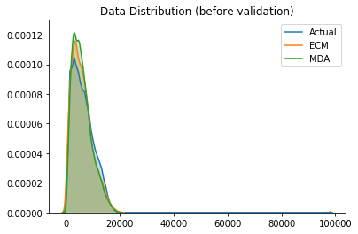

```python
sns.kdeplot(data = wind_actual_generation.Actual, shade = True).set_ylim(0,0.00013)
sns.kdeplot(data = wind_forecast.ECM, shade = True)
sns.kdeplot(data = wind_forecast.MDA, shade = True)
plt.title("Data Distribution (before validation)")
```

We can see that the "Actual Measures" dataset has much more rows (every 5 minutes) than the "Forecasts" dataset (every one hour on the hour), and that their distributions are quite similar.

Joining the two datasets into one, while keeping only the full hours records:

```python
right = wind_actual_generation.set_index('Timestamp')
left = wind_forecast.set_index('Timestamp')
united_full = left.join(right)
united_full
```

| Timestamp | ECM | MDA | Actual |
| --- | --- | --- | --- |
| 2013-01-02 07:00:00+00:00 | 1733.0 | 2039.6 | NaN |
| 2013-01-02 08:00:00+00:00 | 1780.9 | 2137.3 | NaN |
| 2013-01-02 09:00:00+00:00 | 1739.6 | 2090.2 | NaN |
| 2013-01-02 10:00:00+00:00 | 1738.8 | 2169.3 | NaN |
| 2013-01-02 11:00:00+00:00 | 1552.3 | 2163.4 | NaN |
| ... | ... | ... | ... |
| 2019-10-16 01:00:00+00:00 | 10111.0 | 10453.0 | NaN |
| 2019-10-16 02:00:00+00:00 | 11646.0 | 12009.0 | NaN |
| 2019-10-16 03:00:00+00:00 | 12699.0 | 12796.0 | NaN |
| 2019-10-16 04:00:00+00:00 | 12983.0 | 12855.0 | NaN |
| 2019-10-16 05:00:00+00:00 | 12903.0 | 12365.0 | NaN |

59323 rows × 3 columns

Forecasts without real measures to compare to are useless for us, I omit these unnecessary records:

```python
united = united_full.loc[united_full.Actual.notnull()]
united.isna().sum()
```

```
ECM         1
MDA       612
Actual      0
dtype: int64
```

There are (relatively) not many entries with missing values, however, because mine main goal is to compare the two forecast methods I'll omit all the not-full entries.

```python
united = united.loc[united.MDA.notnull() &  united.ECM.notnull()]
```

Let's plot the data on a timeline:

```
Text(0.5,0,'Time')
```

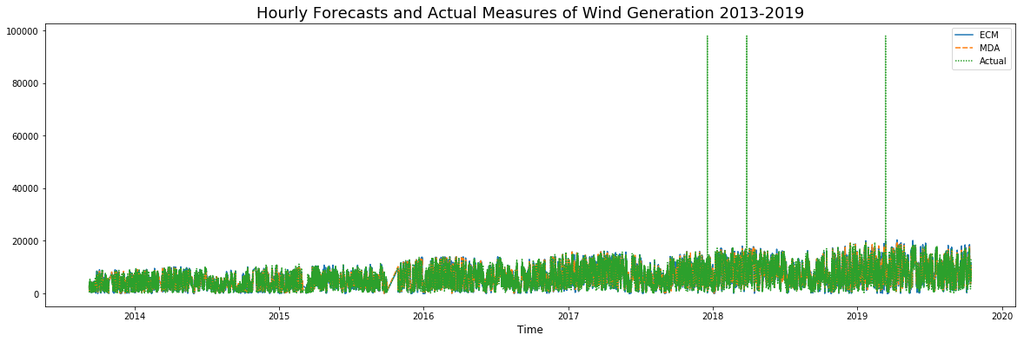

```python
plt.figure(figsize = (20,6))
plt.title("Hourly Forecasts and Actual Measures of Wind Generation 2013-2019", fontsize=18)
sns.lineplot(data = united)
plt.xlabel("Time", fontsize=12)
```

```python
print(united[united['Actual'] > 20000])
print(wind_actual_generation[wind_actual_generation['Actual'] > 20000])
```

```
                               ECM      MDA   Actual
Timestamp
2017-12-18 00:00:00+00:00    184.0    608.0  97944.2
2018-03-27 13:00:00+00:00   7063.0   6015.0  97944.2
2019-03-13 05:00:00+00:00  19554.0  18247.0  97944.2
                       Timestamp   Actual
9139   2013-10-10 09:35:00+00:00  97944.2
37143  2014-01-15 15:35:00+00:00  97944.2
73165  2014-05-22 07:10:00+00:00  97944.2
122415 2014-11-10 07:55:00+00:00  97944.2
135044 2014-12-24 04:45:00+00:00  97944.2
150688 2015-02-16 12:30:00+00:00  97944.2
180443 2015-06-06 18:05:00+00:00  97944.2
207171 2015-09-07 14:10:00+00:00  97944.2
326705 2016-11-24 02:45:00+00:00  97944.2
359081 2017-03-16 12:45:00+00:00  97944.2
431157 2017-11-21 21:50:00+00:00  97944.2
438643 2017-12-18 00:00:00+00:00  97944.2
449584 2018-01-24 23:45:00+00:00  97944.2
467310 2018-03-27 13:00:00+00:00  97944.2
485711 2018-05-30 10:25:00+00:00  97944.2
517018 2018-09-16 03:20:00+00:00  97944.2
518735 2018-09-22 02:25:00+00:00  97944.2
568299 2019-03-13 05:00:00+00:00  97944.2
582921 2019-05-02 23:30:00+00:00  97944.2
606504 2019-07-23 20:45:00+00:00  97944.2
```

The three high values are exactly the same, they come in different months, hours and for very diversed forecasts. Looking in the original full dataset we find not many others ouliers, all with the same exact value, and none of them it adjacent times. These are probably measurement errors, I'll omit them.

```python
united = united[united['Actual'] < 20000]
```

Let's look on the data's statistics, distribution and behavior over time after the cleanup:

```python
united.describe()
```

|  | ECM | MDA | Actual |
| --- | --- | --- | --- |
| count | 51800.000000 | 51800.000000 | 51800.000000 |
| mean | 6260.442040 | 6256.871131 | 6242.147845 |
| std | 3826.035414 | 3615.618322 | 3947.622167 |
| min | 0.000000 | 4.122000 | 13.270000 |
| 25% | 3281.300000 | 3425.425000 | 3018.860000 |
| 50% | 5666.000000 | 5656.950000 | 5616.335000 |
| 75% | 8577.000000 | 8418.000000 | 8871.127500 |
| max | 20350.000000 | 19587.000000 | 19562.070000 |

The two methods and the actual measures have a quite similar statistics. ECM has a bit bigger variance than MDA, while the actual measures has a bigger variance than them both.

The next two graphs support these sayings.

```
Text(0.5,1,'Data Distribution (after validation)')
```

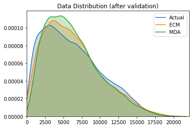

```python
sns.kdeplot(data=united['Actual'], shade=True).set(xlim=(0))
sns.kdeplot(data=united['ECM'], shade=True)
sns.kdeplot(data=united['MDA'], shade=True)
plt.title("Data Distribution (after validation)")
```

```
Text(0,0.5,'Forecast')
```

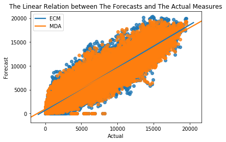

```python
plt.title("The Linear Relation between The Forecasts and The Actual Measures")
sns.regplot(x = united['Actual'], y = united['ECM'])
sns.regplot(x = united['Actual'], y = united['MDA'])
plt.legend(labels = ['ECM', 'MDA'])
plt.ylabel("Forecast")
```

Now the behavior over time:

```
Text(0.5,0,'Time')
```

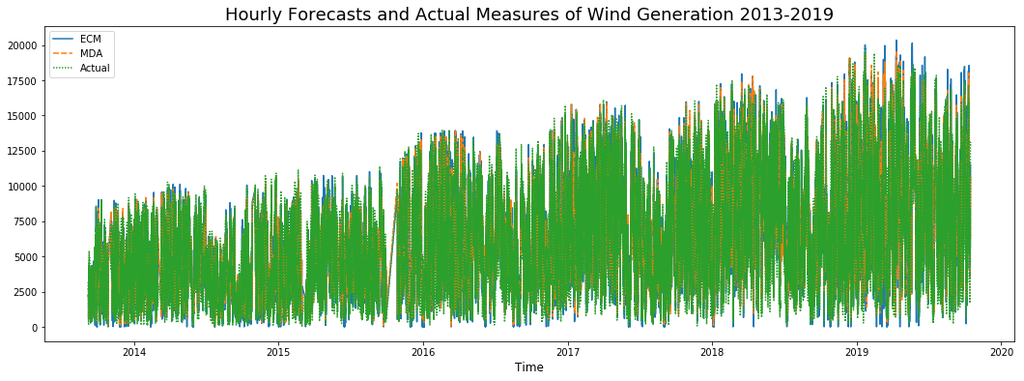

```python
plt.figure(figsize = (18,6))
plt.title("Hourly Forecasts and Actual Measures of Wind Generation 2013-2019", fontsize=18)
sns.lineplot(data = united)
plt.xlabel("Time", fontsize=12)
```

Two first thoughts:

1. It seems that the data's mean and std are increasing with time.
2. It is hard to see if there is a seasonal pattern.

Maybe looking at the graph with monthly averages will help:

```
Text(0.5,0,'Time')
```

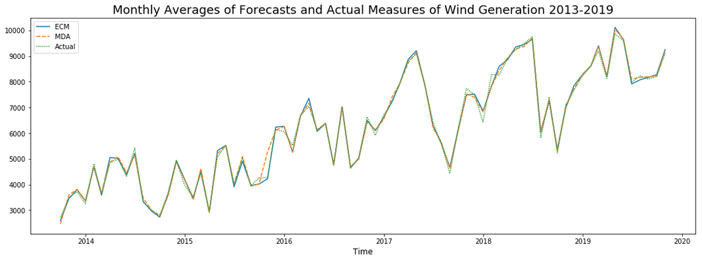

```python
month_avg = united.groupby(pd.Grouper(freq='M')).mean()
plt.figure(figsize = (18,6))
plt.title("Monthly Averages of Forecasts and Actual Measures of Wind Generation 2013-2019", fontsize=18)
sns.lineplot(data = month_avg)
plt.xlabel("Time", fontsize=12)
```

We can see that the forecasts are pretty good on average!

Considering the two points from before:

1. The mean and variance of the measures (and forecats) are definitely increasing. This is not surprising due to the consistent progression of the wind generation industry (growth in number of wind farms and better turbines).
2. It seems there is a weak seasonal pattern, lets look into it:

```
Text(0.5,0,'Month')
```

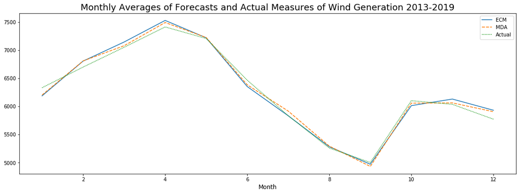

```python
month_avg = united.groupby(united.index.month).mean()
plt.figure(figsize = (18,6))
plt.title("Monthly Averages of Forecasts and Actual Measures of Wind Generation 2013-2019", fontsize=18)
sns.lineplot(data = month_avg)
plt.xlabel("Month", fontsize=12)
```

We can see that, on average, the wind generation increases until a peak at Spring, and then decreases until a minimal value at the end of Summer. In the same manner, another interesting matter is the behavior of the wind generation given the hour of the day:

```
Text(0.5,0,'Hour')
```

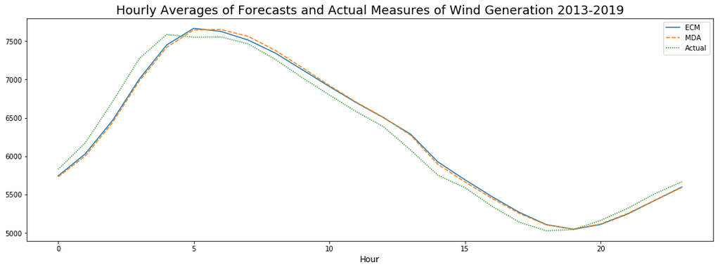

```python
hour_avg = united.groupby(united.index.hour).mean()
plt.figure(figsize = (18,6))
plt.title("Hourly Averages of Forecasts and Actual Measures of Wind Generation 2013-2019", fontsize=18)
sns.lineplot(data = hour_avg)
plt.xlabel("Hour", fontsize=12)
```

Now it is time to add "error" columns:

```python
united['Error_ECM'] = united.apply(lambda row: row.ECM - row.Actual, axis=1)
united['Error_MDA'] = united.apply(lambda row: row.MDA - row.Actual, axis=1)
united.describe()
```

|  | ECM | MDA | Actual | Error_ECM | Error_MDA |
| --- | --- | --- | --- | --- | --- |
| count | 51800.000000 | 51800.000000 | 51800.000000 | 51800.000000 | 51800.000000 |
| mean | 6260.442040 | 6256.871131 | 6242.147845 | 18.294195 | 14.723285 |
| std | 3826.035414 | 3615.618322 | 3947.622167 | 1519.273998 | 1450.439083 |
| min | 0.000000 | 4.122000 | 13.270000 | -8722.840000 | -8373.840000 |
| 25% | 3281.300000 | 3425.425000 | 3018.860000 | -890.677500 | -882.210000 |
| 50% | 5666.000000 | 5656.950000 | 5616.335000 | -8.580000 | 31.225000 |
| 75% | 8577.000000 | 8418.000000 | 8871.127500 | 860.062500 | 880.405000 |
| max | 20350.000000 | 19587.000000 | 19562.070000 | 8333.370000 | 7576.120000 |

Let's plot it:

```
Text(0.5,0,'Time')
```

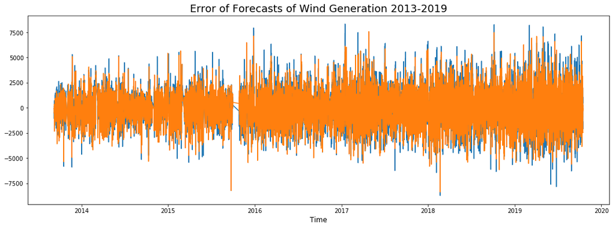

```python
plt.figure(figsize = (18,6))
plt.title("Error of Forecasts of Wind Generation 2013-2019", fontsize=18)
sns.lineplot(data = united['Error_ECM'])
sns.lineplot(data = united['Error_MDA'])
plt.xlabel("Time", fontsize=12)
```

In accordance with previous graphs, where the variance of the measures grew over time, also the errors are getting bigger with time.

```
Text(0.5,1,'Errors Distribution')
```

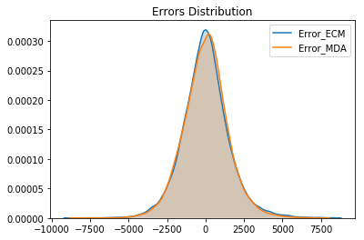

```python
sns.kdeplot(data = united['Error_ECM'], shade = True)
sns.kdeplot(data = united['Error_MDA'], shade = True)
plt.title("Errors Distribution")
```

It seems that the error of the ECM method has a normal distribution with mean close to zero, while the error of the MDA method distributes somewhat similar, but with a positive sqew around the middle (has more over-assessing small errors than under-assessing small errors).

For quantitative analysis of the performance of the forecasts I calculate the Mean Absolute Error:

```python
MAE_ECM = np.mean(np.absolute(united.Error_ECM))
MAE_MDA = np.mean(np.absolute(united.Error_MDA))
print("The Mean Absolute Error of the ECM method is: {:.6}\nThe Mean Absolute Error of the MDA method is: {:.6}".format(MAE_ECM, MAE_MDA))
```

```
The Mean Absolute Error of the ECM method is: 1137.33
The Mean Absolute Error of the MDA method is: 1110.81
```

```python
print(np.absolute(united['Error_ECM']).describe())
print(np.absolute(united['Error_MDA']).describe())
```

```
count    51800.000000
mean      1137.330352
std       1007.463579
min          0.070000
25%        396.677500
50%        874.785000
75%       1582.270000
max       8722.840000
Name: Error_ECM, dtype: float64
count    51800.000000
mean      1110.808215
std        932.776287
min          0.000000
25%        410.610000
50%        881.255000
75%       1563.112500
max       8373.840000
Name: Error_MDA, dtype: float64
```

The errors of the two methods seem to distribute fairly similar (which is not surprising, due to the observation that the two forecasts distribute similar).

Looking on the performance in different periods - hourly and monthly:

```
Text(0.5,0,'Hour')
```

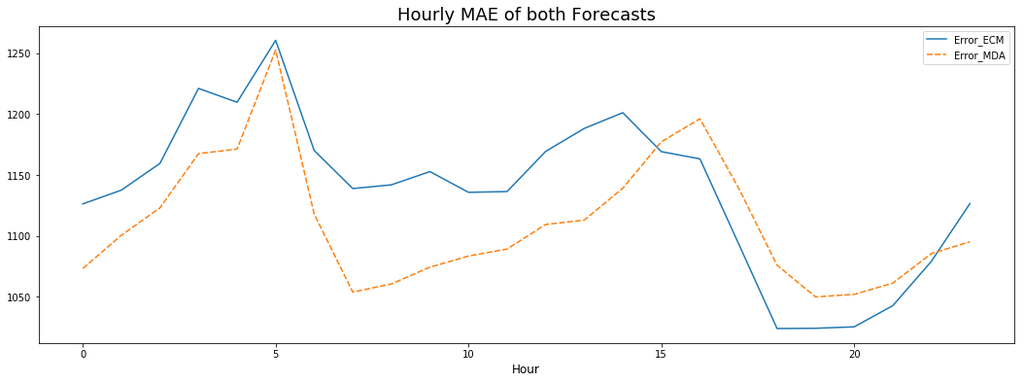

```python
hour_error = pd.concat([np.absolute(united['Error_ECM']).groupby(united.index.hour).mean(), np.absolute(united['Error_MDA']).groupby(united.index.hour).mean()], axis = 1)
plt.figure(figsize = (18,6))
plt.title("Hourly MAE of both Forecasts", fontsize=18)
sns.lineplot(data = hour_error)
plt.xlabel("Hour", fontsize=12)
```

```
Text(0.5,0,'Month')
```

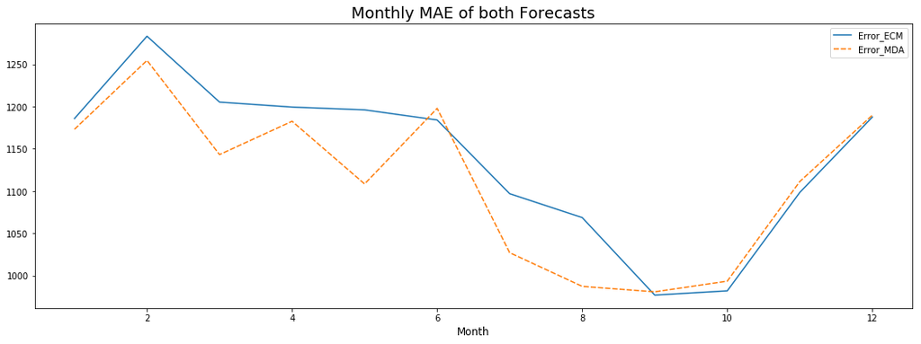

```python
month_error = pd.concat([np.absolute(united['Error_ECM']).groupby(united.index.month).mean(), np.absolute(united['Error_MDA']).groupby(united.index.month).mean()], axis = 1)
plt.figure(figsize = (18,6))
plt.title("Monthly MAE of both Forecasts", fontsize=18)
sns.lineplot(data = month_error)
plt.xlabel("Month", fontsize=12)
```

It looks like there is nothing distinct, but carefully one can point to a better result of the MDA method when the wind generation is strong (around morning and Spring), and on contrary when the wind generation is weak (evening and Autumn).

It is worth doing a statistical hypothesis testing for checking if the two methods are significantly different statistically. Due to the large size of the samples it is fine to assume that the errors (or the forecasts, it's the same) are normally distributed (it's also easy to see that from the graph). I executed a t-test, and as it possible to see from the very high p-value, we can't reject the null hypothesis (with a good significance level) that these two columns have the same mean (and indeed the averages of these two are very close, and small comparing to the variance).

```python
stats.ttest_ind(united['Error_ECM'],united['Error_MDA'],equal_var = False)
```

```
Ttest_indResult(statistic=0.38692573063026137, pvalue=0.6988119881368282)
```

So for conclusion, in my opinion, it's not really appropriate to point at one of the methods as better. The ECM error is a bit more centered, the MDA error has a bit smaller mean and variance, but overall, the two methods are similar and about the same quality.

I would say that both methods are sufficiently accurate and the criterion for chossing between them should be a matter of costs (i.e., which is easyer/cheaper/faster to produce), comfort or other domains.

**An analysis tool**